# Project: Investigate a Dataset - [TMDB movie data]

- Introduction
- Data Wrangling
- Exploratory Data Analysis
- Conclusions

## Introduction

### Dataset Description

#### Columns Names

1.id - Rows unique id

2.imdb_id - imdb unique id

3.popularity - popularity score

4.budget - budget of movie

5.revenue - revenue of movie

6.original_title - Movie title

7.cast - cast in movie

8.homepage - link to movie website

9.director - movie director name

10.tagline - tagline of movie

11.keywords - movie keywords

12.overview - overview of movie

13.runtime - movie duration in minutes

14.genres - movie category

15.production_companies - name of company that produced movie

16.release_date - release date of movie

17.vote_count - vote casted by viewers or reviewers

18.vote_average - average vote casted by viewers or reviewers

19.release_year - year movie was released

20.budget_adj-budget in 2010 dollars,accounting for inflation

21.revenue_adj -revenue in 2010 dollars,accounting for inflation

### Question(s) for Analysis

> Which movie genre are the most popular ?

> Which casts are the most popular ?

> Which year has the highest number of movie released ?

> Which year made the highest and lowest profit ?

```python
# Use this cell to set up import statements for all of the packages that you
#   plan to use.

# Remember to include a 'magic word' so that your visualizations are plotted
#   inline with the notebook. See this page for more:
#   http://ipython.readthedocs.io/en/stable/interactive/magics.html
import pandas as pd
import numpy as np
import matplotlib.pyplot as plt
import seaborn as sns
%matplotlib inline
```

```python
# Upgrade pandas to use dataframe.explode() function.
!pip install --upgrade pandas==0.25.0
```

## Data Wrangling

Exploring data :

```python
# Load your data and print out a few lines. Perform operations to inspect data
#   types and look for instances of missing or possibly errant data.

tmdb = pd.read_csv('tmdb-movies.csv')
tmdb.head()
```

|  | id | imdb_id | popularity | budget | revenue | original_title | cast | homepage | director | tagline | ... | overview | runtime | genres | production_companies | release_date | vote_count | vote_average | release_year | budget_adj | revenue_adj |
| --- | --- | --- | --- | --- | --- | --- | --- | --- | --- | --- | --- | --- | --- | --- | --- | --- | --- | --- | --- | --- | --- |
| 0 | 135397 | tt0369610 | 32.985763 | 150000000 | 1513528810 | Jurassic World | Chris Pratt\|Bryce Dallas Howard\|Irrfan Khan\|Vi... | http://www.jurassicworld.com/ | Colin Trevorrow | The park is open. | ... | Twenty-two years after the events of Jurassic ... | 124 | Action\|Adventure\|Science Fiction\|Thriller | Universal Studios\|Amblin Entertainment\|Legenda... | 6/9/15 | 5562 | 6.5 | 2015 | 1.379999e+08 | 1.392446e+09 |
| 1 | 76341 | tt1392190 | 28.419936 | 150000000 | 378436354 | Mad Max: Fury Road | Tom Hardy\|Charlize Theron\|Hugh Keays-Byrne\|Nic... | http://www.madmaxmovie.com/ | George Miller | What a Lovely Day. | ... | An apocalyptic story set in the furthest reach... | 120 | Action\|Adventure\|Science Fiction\|Thriller | Village Roadshow Pictures\|Kennedy Miller Produ... | 5/13/15 | 6185 | 7.1 | 2015 | 1.379999e+08 | 3.481613e+08 |
| 2 | 262500 | tt2908446 | 13.112507 | 110000000 | 295238201 | Insurgent | Shailene Woodley\|Theo James\|Kate Winslet\|Ansel... | http://www.thedivergentseries.movie/#insurgent | Robert Schwentke | One Choice Can Destroy You | ... | Beatrice Prior must confront her inner demons ... | 119 | Adventure\|Science Fiction\|Thriller | Summit Entertainment\|Mandeville Films\|Red Wago... | 3/18/15 | 2480 | 6.3 | 2015 | 1.012000e+08 | 2.716190e+08 |
| 3 | 140607 | tt2488496 | 11.173104 | 200000000 | 2068178225 | Star Wars: The Force Awakens | Harrison Ford\|Mark Hamill\|Carrie Fisher\|Adam D... | http://www.starwars.com/films/star-wars-episod... | J.J. Abrams | Every generation has a story. | ... | Thirty years after defeating the Galactic Empi... | 136 | Action\|Adventure\|Science Fiction\|Fantasy | Lucasfilm\|Truenorth Productions\|Bad Robot | 12/15/15 | 5292 | 7.5 | 2015 | 1.839999e+08 | 1.902723e+09 |
| 4 | 168259 | tt2820852 | 9.335014 | 190000000 | 1506249360 | Furious 7 | Vin Diesel\|Paul Walker\|Jason Statham\|Michelle ... | http://www.furious7.com/ | James Wan | Vengeance Hits Home | ... | Deckard Shaw seeks revenge against Dominic Tor... | 137 | Action\|Crime\|Thriller | Universal Pictures\|Original Film\|Media Rights ... | 4/1/15 | 2947 | 7.3 | 2015 | 1.747999e+08 | 1.385749e+09 |

5 rows × 21 columns

```python
tmdb.shape
```

```
(10866, 21)
```

```python
tmdb.info()
```

```
<class 'pandas.core.frame.DataFrame'>
RangeIndex: 10866 entries, 0 to 10865
Data columns (total 21 columns):
id                      10866 non-null int64
imdb_id                 10856 non-null object
popularity              10866 non-null float64
budget                  10866 non-null int64
revenue                 10866 non-null int64
original_title          10866 non-null object
cast                    10790 non-null object
homepage                2936 non-null object
director                10822 non-null object
tagline                 8042 non-null object
keywords                9373 non-null object
overview                10862 non-null object
runtime                 10866 non-null int64
genres                  10843 non-null object
production_companies    9836 non-null object
release_date            10866 non-null object
vote_count              10866 non-null int64
vote_average            10866 non-null float64
release_year            10866 non-null int64
budget_adj              10866 non-null float64
revenue_adj             10866 non-null float64
dtypes: float64(4), int64(6), object(11)
memory usage: 1.7+ MB
```

### Data Cleaning

Make data fit for my analysis

```python
#remove unused columns
tmdb.drop(labels = ['imdb_id','homepage', 'budget_adj', 'revenue_adj'],axis =1,inplace =True)
```

```python
tmdb.shape
```

```
(10866, 17)
```

```python
#remove duplicates
sum(tmdb.duplicated())
tmdb.drop_duplicates(keep= 'first',inplace = True)
```

```python
#check results
sum(tmdb.duplicated())
```

```
0
```

```python
#fix null
tmdb.isnull().sum()
```

```
id                         0
popularity                 0
budget                     0
revenue                    0
original_title             0
cast                      76
director                  44
tagline                 2824
keywords                1493
overview                   4
runtime                    0
genres                    23
production_companies    1030
release_date               0
vote_count                 0
vote_average               0
release_year               0
dtype: int64
```

```python
#drop null
tmdb.dropna(inplace=True)
```

```python
#check results
tmdb.isnull().sum().any()
```

```
False
```

```python
tmdb.shape
```

```
(7031, 17)
```

```python
#ist
data_zero = ['runtime','budget','revenue']

# value from zero to NAN
tmdb[data_zero] = tmdb[data_zero].replace(0, np.NAN)

#Removing all NaN value
tmdb.dropna(subset = data_zero, inplace = True)

tmdb.shape
```

```
(3445, 17)
```

```python
tmdb.info()
```

```
<class 'pandas.core.frame.DataFrame'>
Int64Index: 3445 entries, 0 to 10848
Data columns (total 17 columns):
id                      3445 non-null int64
popularity              3445 non-null float64
budget                  3445 non-null float64
revenue                 3445 non-null float64
original_title          3445 non-null object
cast                    3445 non-null object
director                3445 non-null object
tagline                 3445 non-null object
keywords                3445 non-null object
overview                3445 non-null object
runtime                 3445 non-null float64
genres                  3445 non-null object
production_companies    3445 non-null object
release_date            3445 non-null object
vote_count              3445 non-null int64
vote_average            3445 non-null float64
release_year            3445 non-null int64
dtypes: float64(5), int64(3), object(9)
memory usage: 484.5+ KB
```

```python
tmdb['release_date'] = pd.to_datetime(tmdb['release_date'])
tmdb.dtypes
```

```
id                               int64
popularity                     float64
budget                         float64
revenue                        float64
original_title                  object
cast                            object
director                        object
tagline                         object
keywords                        object
overview                        object
runtime                        float64
genres                          object
production_companies            object
release_date            datetime64[ns]
vote_count                       int64
vote_average                   float64
release_year                     int64
dtype: object
```

> clean data :

> Drop unused columns

> remove duplicates

> remove null values

## Exploratory Data Analysis

### Research Question 1 (Which movie genre are the most popular?)

```python
def sort_num(col_name):

    sort_num = tmdb[col_name].str.cat(sep = '|')
    sort_num = pd.Series(sort_num.split('|'))
    freq = sort_num.value_counts(ascending = False)

    return freq
```

```python
genres = sort_num('genres')

genres
```

```
Drama              1515
Comedy             1199
Thriller           1112
Action             1013
Adventure           698
Crime               593
Romance             566
Science Fiction     497
Horror              436
Family              387
Fantasy             371
Mystery             323
Animation           185
History             112
Music               109
War                 107
Western              48
Documentary          23
Foreign               6
TV Movie              1
dtype: int64
```

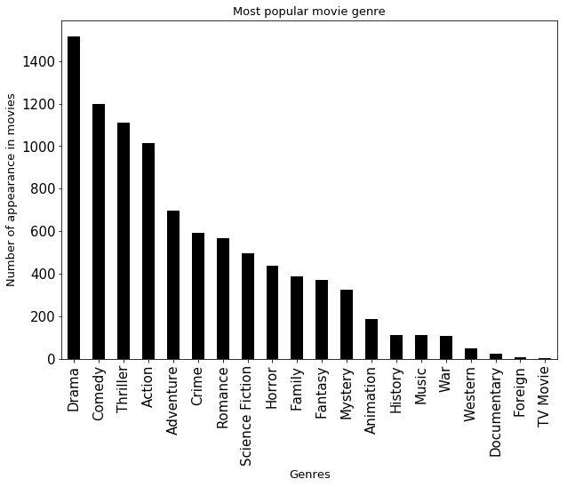

```python
#plot
genres_bar = genres.plot.bar(color = 'black', fontsize = 15)

genres_bar.figure.set_size_inches(10, 7);

#labels
plt.title('Most popular movie genre', color = 'black', fontsize = '13')
plt.xlabel('Genres', color = 'black', fontsize = '13')
plt.ylabel('Number of appearance in movies', color = 'black', fontsize = '13');
```

visualization shows Drama is the most popular genre by with 1515 appearances

### Research Question 2 (Which casts are the most popular)

```python
cast = sort_num('cast')
#printing top 10 value
Top10_cast = cast.head(10)
```

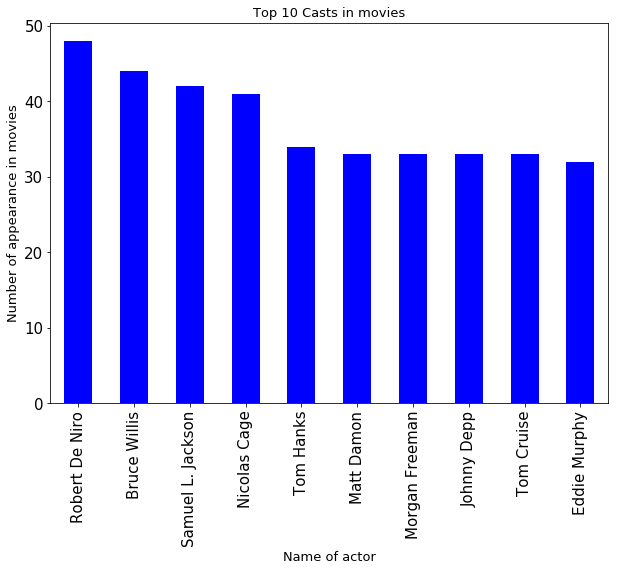

```python
#plot
cast_bar = Top10_cast.plot.bar(color = 'blue', fontsize = 15)
cast_bar.figure.set_size_inches(10, 7);

#labels
plt.title('Top 10 Casts in movies', color = 'black', fontsize = '13')
plt.xlabel('Name of actor', color = 'black', fontsize = '13')
plt.ylabel('Number of appearance in movies', color = 'black', fontsize = '13');
```

visualization shows Robert De Niro has the highest number of appearance

### Research Question 3 (Which year has the highest number of movie released)

```python
# Group by year then count the number of movies.
year_movie = tmdb.groupby('release_year')['original_title'].count()
year_movie.head()
```

```
release_year
1960    4
1961    9
1962    7
1963    6
1964    7
Name: original_title, dtype: int64
```

```python
#highest number
year_movie.idxmax()
```

```
2011
```

```python
#lowest number
year_movie.idxmin()
```

```
1960
```

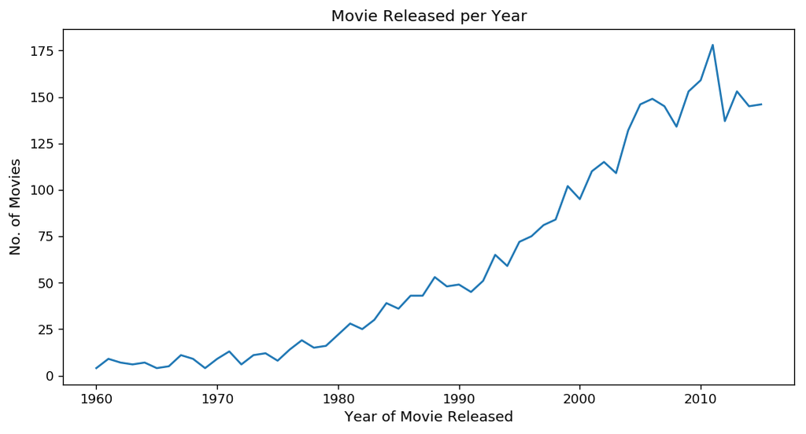

```python
#plot
plt.figure(figsize=(10,5), dpi = 120)

#labels
plt.xlabel('Year of Movie Released', fontsize = 11)
plt.ylabel('No. of Movies', fontsize = 11)
plt.title('Movie Released per Year')

plt.plot(year_movie)

# Display plot
plt.show()
```

2011 showing the highest movie produced

### Research Question 4 (Which year made the highest and lowest profit)

```python
tmdb.head()
```

|  | id | popularity | budget | revenue | original_title | cast | director | tagline | keywords | overview | runtime | genres | production_companies | release_date | vote_count | vote_average | release_year |
| --- | --- | --- | --- | --- | --- | --- | --- | --- | --- | --- | --- | --- | --- | --- | --- | --- | --- |
| 0 | 135397 | 32.985763 | 150000000.0 | 1.513529e+09 | Jurassic World | Chris Pratt\|Bryce Dallas Howard\|Irrfan Khan\|Vi... | Colin Trevorrow | The park is open. | monster\|dna\|tyrannosaurus rex\|velociraptor\|island | Twenty-two years after the events of Jurassic ... | 124.0 | Action\|Adventure\|Science Fiction\|Thriller | Universal Studios\|Amblin Entertainment\|Legenda... | 2015-06-09 | 5562 | 6.5 | 2015 |
| 1 | 76341 | 28.419936 | 150000000.0 | 3.784364e+08 | Mad Max: Fury Road | Tom Hardy\|Charlize Theron\|Hugh Keays-Byrne\|Nic... | George Miller | What a Lovely Day. | future\|chase\|post-apocalyptic\|dystopia\|australia | An apocalyptic story set in the furthest reach... | 120.0 | Action\|Adventure\|Science Fiction\|Thriller | Village Roadshow Pictures\|Kennedy Miller Produ... | 2015-05-13 | 6185 | 7.1 | 2015 |
| 2 | 262500 | 13.112507 | 110000000.0 | 2.952382e+08 | Insurgent | Shailene Woodley\|Theo James\|Kate Winslet\|Ansel... | Robert Schwentke | One Choice Can Destroy You | based on novel\|revolution\|dystopia\|sequel\|dyst... | Beatrice Prior must confront her inner demons ... | 119.0 | Adventure\|Science Fiction\|Thriller | Summit Entertainment\|Mandeville Films\|Red Wago... | 2015-03-18 | 2480 | 6.3 | 2015 |
| 3 | 140607 | 11.173104 | 200000000.0 | 2.068178e+09 | Star Wars: The Force Awakens | Harrison Ford\|Mark Hamill\|Carrie Fisher\|Adam D... | J.J. Abrams | Every generation has a story. | android\|spaceship\|jedi\|space opera\|3d | Thirty years after defeating the Galactic Empi... | 136.0 | Action\|Adventure\|Science Fiction\|Fantasy | Lucasfilm\|Truenorth Productions\|Bad Robot | 2015-12-15 | 5292 | 7.5 | 2015 |
| 4 | 168259 | 9.335014 | 190000000.0 | 1.506249e+09 | Furious 7 | Vin Diesel\|Paul Walker\|Jason Statham\|Michelle ... | James Wan | Vengeance Hits Home | car race\|speed\|revenge\|suspense\|car | Deckard Shaw seeks revenge against Dominic Tor... | 137.0 | Action\|Crime\|Thriller | Universal Pictures\|Original Film\|Media Rights ... | 2015-04-01 | 2947 | 7.3 | 2015 |

```python
#create new
tmdb['movie_profit'] = tmdb['revenue'] - tmdb['budget']

tmdb.head(1)
```

|  | id | popularity | budget | revenue | original_title | cast | director | tagline | keywords | overview | runtime | genres | production_companies | release_date | vote_count | vote_average | release_year | movie_profit |
| --- | --- | --- | --- | --- | --- | --- | --- | --- | --- | --- | --- | --- | --- | --- | --- | --- | --- | --- |
| 0 | 135397 | 32.985763 | 150000000.0 | 1.513529e+09 | Jurassic World | Chris Pratt\|Bryce Dallas Howard\|Irrfan Khan\|Vi... | Colin Trevorrow | The park is open. | monster\|dna\|tyrannosaurus rex\|velociraptor\|island | Twenty-two years after the events of Jurassic ... | 124.0 | Action\|Adventure\|Science Fiction\|Thriller | Universal Studios\|Amblin Entertainment\|Legenda... | 2015-06-09 | 5562 | 6.5 | 2015 | 1.363529e+09 |

```python
# Group by year profit.
profit_per_year = tmdb.groupby('release_year')['movie_profit'].sum()
```

```python
#highest profit
profit_per_year.idxmax()
```

```
2015
```

```python
#lowest profit
profit_per_year.idxmin()
```

```
1966
```

[figure not shown]

```python
# Plot
plt.figure(figsize=(10,5), dpi = 120)

#labels
plt.xlabel('Year of Movie Released', fontsize = 11)
plt.ylabel('Profit', fontsize = 11)
plt.title('Profit by movie released in a year')
plt.plot(year_movie)

#Display
plt.show()
```

2015 made the highest profit in movie production

## Research Question 5 (Movies with longest and shortest runtime)

```python
import pprint
def calculate(column):
    #for highest earned profit
    high= tmdb[column].idxmax()
    high_details=pd.DataFrame(tmdb.loc[high])

    #for lowest earned profit
    low= tmdb[column].idxmin()
    low_details=pd.DataFrame(tmdb.loc[low])

    #collectin data in one place
    info=pd.concat([high_details, low_details], axis=1)

    return info
```

```python
calculate('runtime')
```

|  | 2107 | 8005 |
| --- | --- | --- |
| id | 43434 | 14813 |
| popularity | 0.534192 | 0.592219 |
| budget | 1.8e+07 | 3e+06 |
| revenue | 871279 | 2.1e+07 |
| original_title | Carlos | Mickey's Christmas Carol |
| cast | Edgar RamÃrez\|Alexander Scheer\|Fadi Abi Samra... | Alan Young\|Wayne Allwine\|Clarence Nash\|Hal Smi... |
| director | Olivier Assayas | Burny Mattinson |
| tagline | The man who hijacked the world | He's back! Mickey Mouse - in his first new mot... |
| keywords | gun\|car bomb\|tv mini-series\|terrorism\|opec | cartoon\|scrooge\|ghost\|charles dickens\|christmas |
| overview | The story of Venezuelan revolutionary, Ilich R... | It is an adaptation of the Charles Dickens cla... |
| runtime | 338 | 26 |
| genres | Crime\|Drama\|Thriller\|History | Family\|Animation |
| production_companies | Egoli Tossell Film AG\|Canal+\|Arte France\|Films... | Walt Disney Pictures |
| release_date | 2010-05-19 00:00:00 | 1983-10-19 00:00:00 |
| vote_count | 35 | 89 |
| vote_average | 6.2 | 7.4 |
| release_year | 2010 | 1983 |
| movie_profit | -1.71287e+07 | 1.8e+07 |

Column with id 2107 shows the longest runtime i.e 338 minutes.

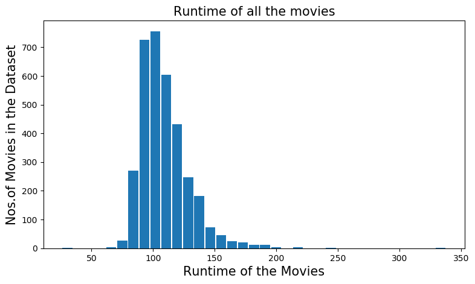

```python
#plot

plt.figure(figsize=(9,5), dpi = 100)

#labels
plt.xlabel('Runtime of the Movies', fontsize = 15)
plt.ylabel('Nos.of Movies in the Dataset', fontsize=15)
plt.title('Runtime of all the movies', fontsize=15)

#Histogram
plt.hist(tmdb['runtime'], rwidth = 0.9, bins =35)
#Display
plt.show()
```

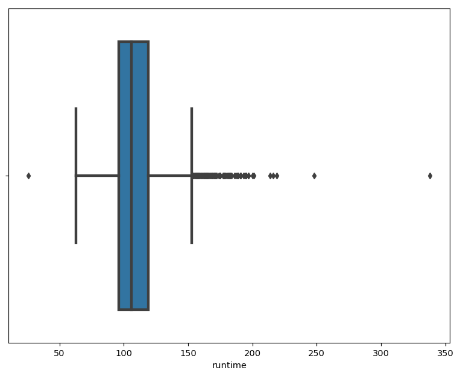

```python
#import seaborn
import seaborn as sns

#boxplot
plt.figure(figsize=(9,7), dpi = 105)
sns.boxplot(tmdb['runtime'], linewidth = 3)

#Diplay
plt.show()
```

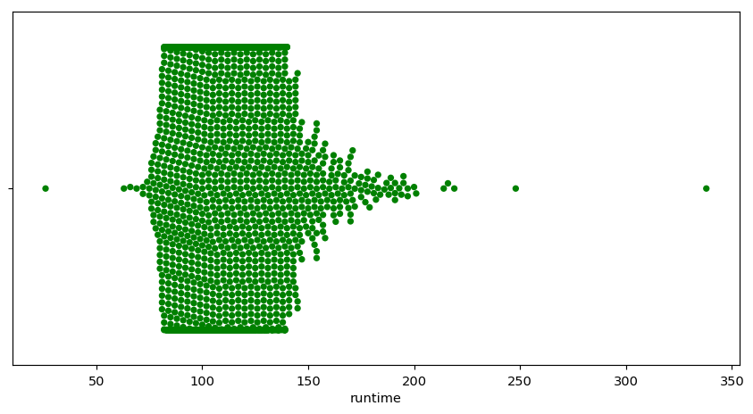

```python
#plot
plt.figure(figsize=(10,5), dpi = 105)
sns.swarmplot(tmdb['runtime'], color = 'green')
#Display
plt.show()
```

Visualizing runtime of movies and the max,min points

## Conclusions

1- 1960 to 2015: Drama was produced more than any other movie genre.

2- the most popular cast. Robert De Niro.

3- yearly trend in movie production : 2011 which is the year with the highest number of movie released with 178 movies produced. While year 1960 had the lowest

4- yearly trend in profit made from movies. Which shows year 2015 made the highest profit in movie production.

## Limitations

had to drop so many rows as they have missing values.

budget and revenue column do not have currency unit.

data has reevenue with 50 m which for sure include mistakes.

## Submitting your Project

```python
from subprocess import call
call(['python', '-m', 'nbconvert', 'Investigate_a_Dataset.ipynb'])
```